# STC markdown

KJ

2023-04-25

Minimal data and markdown for STC data, Aitken et al, 2023. PLoS ONE This is the data to replicate study findings using methods for plotting. The utilized statistical methods in R will be loaded at a later date, or can be requested, but for the most part anova with post-hoc t.tests were performed.

For this work, the R version and the OS it is run on are listed here: R version 4.2.2 (2022-10-31) Platform: x86_64-apple-darwin17.0 (64-bit) Running under: macOS High Sierra 10.13.6

Version for other attached packages:

[1] beeswarm_0.4.0 reshape2_1.4.4 rmarkdown_2.20 stats_4.2.2 readxl_1.4.2  
[6] fontawesome_0.5.1 tidyverse_2.0.0 tidyr_1.3.0 RColorBrewer_1.1-3 FactoMineR_2.7 [11] dplyr_1.1.0 purrr_1.0.1 tibble_3.2.0 knitr_1.42 Hmisc_5.0-1 [16] data.table_1.14.8 ggplot2_3.4.1 robustbase_0.95-0 readr_2.1.4 stats_4.2.2

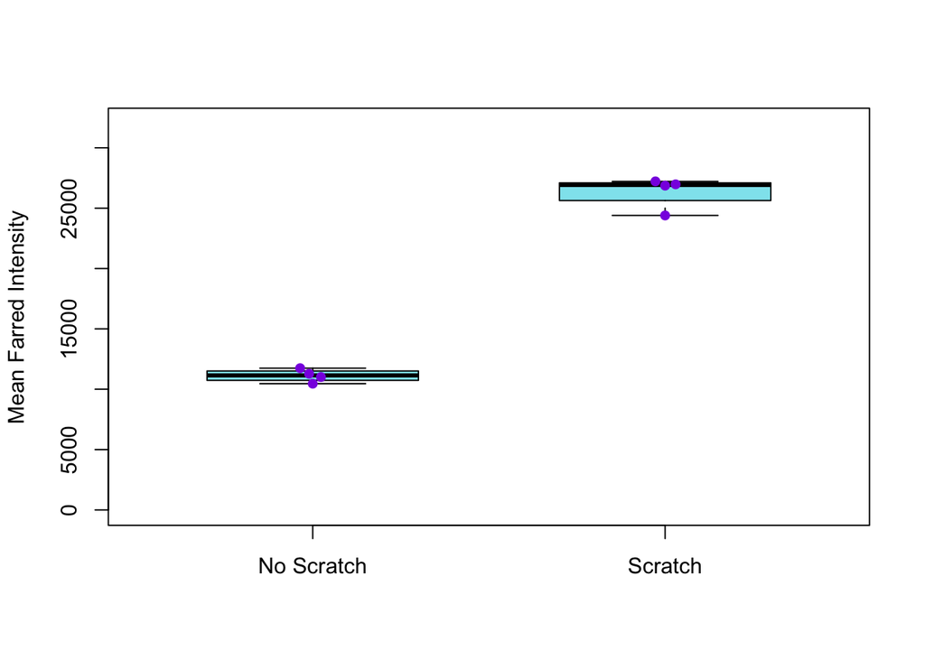

```r
#Fig 1b
library(beeswarm)
library(RColorBrewer)
library(readr)

# upload data from github
yap_scratch_wound <- read_csv("https://raw.githubusercontent.com/kjaitken/STC_repository/main/github%20datasets/yap_scratch_wound.csv")
yapscr <-yap_scratch_wound

f <- ordered(yapscr$Group,levels = c("no scratch","scratch"), labels = c("No Scratch","Scratch"))

boxplot(nucl.intens_per_well ~ f, data =yapscr,pch = 18, xlab = "",ylab = "Mean Farred Intensity",   col= "cadetblue2", ylim=c(1, 32000), boxwex = 0.6, labels= c("No Scratch", "Scratch"), alpha = 0.3)
beeswarm(nucl.intens_per_well ~ f, data =yapscr, pch = 16, xlab = "", las = 2,cex.axis=1, ylab = "Mean Farred Intensity",col= "blueviolet", cex.lab = 0.5, add= TRUE)
```

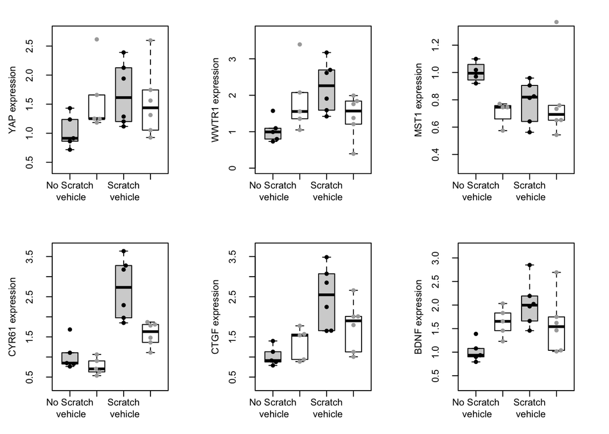

```r
#fig 1D and E composite

#upload data from github:
scrPCR <- read_csv("https://raw.githubusercontent.com/kjaitken/STC_repository/main/github%20datasets/scrPCR.csv")
View(scrPCR)
#n=5 for first two groups, and n = 6 for the next two, because the RNA quality was not good for two samples - one in each of first two groups.
#remove NA's filling bottom rows (not sure why these were added on here)
scrPCR<-scrPCR[1:22,]

#graphing methods:

f <- ordered(scrPCR$Group,levels = c("no scratch veh","no scratch VP","scratch veh","scratch VP"), labels = c("No Scratch\n vehicle","No Scratch\n VP", "Scratch\n vehicle", "Scratch\n VP"))

#bottom left top right margins, 3 columns of plots, and margins for the x axis labels.
par(mai=c(0.4,0.40,0.2,0.2) +0.2, xpd = TRUE, mfrow = c(1,3),mgp = c(3,1.5,0))

f <- ordered(scrPCR$Group,levels = c("no scratch veh","no scratch VP","scratch veh","scratch VP"), labels = c("No Scratch\n vehicle","No Scratch\n VP", "Scratch\n vehicle", "Scratch\n VP"))

#bottom left top right margins, extra space on the outer edge, 3 columns of plots, and margins for the x axis labels.
par(mai=c(0.3,0.40,0.1,0.2) +0.2, xpd = TRUE, mfrow = c(2,3),mgp = c(3,1.5,0))

boxplot(linYAP ~ f, data =scrPCR,pch = 18, xlab = "", ylab = "YAP expression", col= c("light gray", "white","light gray", "white"), ylim=c(0.4, 2.75), boxwex = 0.6)
beeswarm(linYAP ~ f, data =scrPCR, pch = 16, xlab = "", las = 2, ylab = "YAP expression",
col= c("black","dark grey","black","dark grey"), cex.lab = 0.5, add= TRUE)

boxplot(linWWTR1 ~ f, data =scrPCR,pch = 18, xlab = "",ylab = "WWTR1 expression", col= c("light gray", "white","light gray", "white"), ylim=c(0, 3.75), boxwex = 0.6)
beeswarm(linWWTR1 ~ f, data =scrPCR, pch = 16, xlab = "", las = 2,ylab = "WWTR1 expression",
col= c("black","dark grey","black","dark grey"), cex.lab = 0.5, add= TRUE)

boxplot(linMST ~ f, data =scrPCR,pch = 18, xlab = "",ylab = "MST1 expression", col= c("light gray", "white","light gray", "white"), ylim=c(0.3, 1.3), boxwex = 0.6)
beeswarm(linMST ~ f, data =scrPCR, pch = 16, xlab = "", las = 2, ylab = "MST1 expression",
col= c("black","dark grey","black","dark grey"), cex.lab = 0.5, add= TRUE)

boxplot(linCYR61 ~ f, data =scrPCR,pch = 18, xlab = "",ylab = "CYR61 expression", col= c("light gray", "white","light gray", "white"), ylim=c(0.3, 3.7), boxwex = 0.6)
beeswarm(linCYR61 ~ f, data =scrPCR, pch = 16, xlab = "", las = 2,cex.axis=1, ylab = "CYR61 expression",
col= c("black","dark grey","black","dark grey"), cex.lab = 0.5, add= TRUE)

boxplot(linCTGF.1 ~ f, data =scrPCR,pch = 18, xlab = "",ylab = "CTGF expression", col= c("light gray", "white","light gray", "white"), ylim=c(0.3, 3.7), boxwex = 0.6 )
beeswarm(linCTGF.1 ~ f, data =scrPCR, pch = 16, xlab = "", las = 2,cex.axis=1, ylab = "CTGF expression",
col= c("black","dark grey","black","dark grey"), cex.lab = 0.5, add= TRUE)

boxplot(linearBDNF ~ f, data =scrPCR,pch = 18, xlab = "",ylab = "BDNF expression", col= c("light gray", "white","light gray", "white"), ylim=c(0.3, 3.2), boxwex = 0.6)
beeswarm(linearBDNF ~ f, data =scrPCR, pch = 16, xlab = "", las = 2,cex.axis=1, ylab = "BDNF expression",
col= c("black","dark grey","black","dark grey"), cex.lab = 0.5, add= TRUE)
```

Bladder weight and residual volume data:

```r
library(readr)
library(beeswarm)
#stcp file of phys data: provided in github:
STCphysandPCR <- read_csv("https://raw.githubusercontent.com/kjaitken/STC_repository/main/github%20datasets/STCphysandPCR.csv")
```

```
## ──────────────────────────────────────────────────────── Delimiter: "," chr
## (2): Group, weeks dbl (24): cage, sample, month.of.surgery, day.of.surgery,
## weight.on.day0, we... lgl (10): ...27, ...28, ...29, ...30, ...31, ...32,
## ...33, ...34, ...35, ...36
```

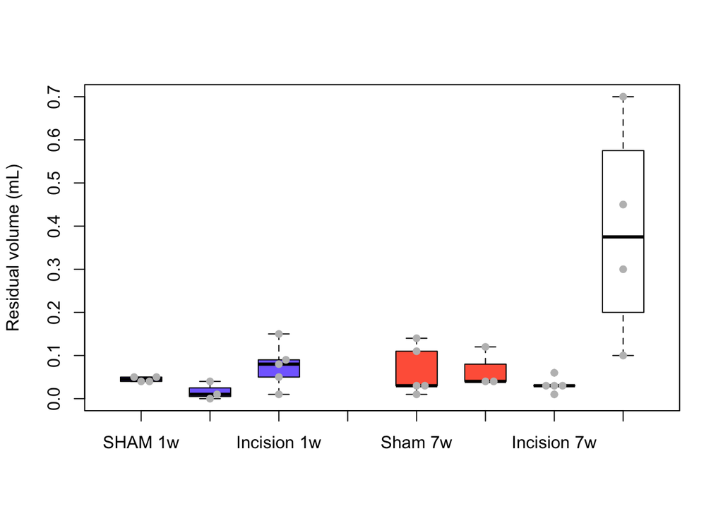

```r
#remove extraneous columns
stcp<-STCphysandPCR[,1:26]

#removed one extreme outlier from PBO 7 week group, which had 3ml residual volume in row 25).
f <- ordered(interaction(stcp[c(1:24,26:40),]$Group,stcp[c(1:24,26:40),]$weeks),levels = c("SHAM.1wk", "STC.1wk","Incision.1wk", "PBO.1wk","SHAM.7wk", "STC.7wk","Incision.7wk", "PBO.7wk"))
boxplot(RV ~ f, data =stcp[c(1:24,26:40),],pch = 18, xlab = "",ylab = "Residual volume (mL)", boxwex=0.6 ,col=c("slateblue1","slateblue1","slateblue1","slateblue1","tomato","tomato","tomato","white"),names= c("SHAM 1w", "STC 1w","Incision 1w", "", "Sham 7w", "STC 7w","Incision 7w", "PBO 7w"))
beeswarm(RV ~ f, data =stcp[c(1:24,26:40),], pch = 16, xlab = "", las = 2,cex.axis=1, ylab = "Residual volume (mL)",names= c("SHAM 1w", "STC 1w","Incision 1w", "", "Sham 7w", "STC 7w","Incision 7w", "PBO 7w"),col= "grey", cex.axis = 0.8, cex.lab = 1.5, add=TRUE)
```

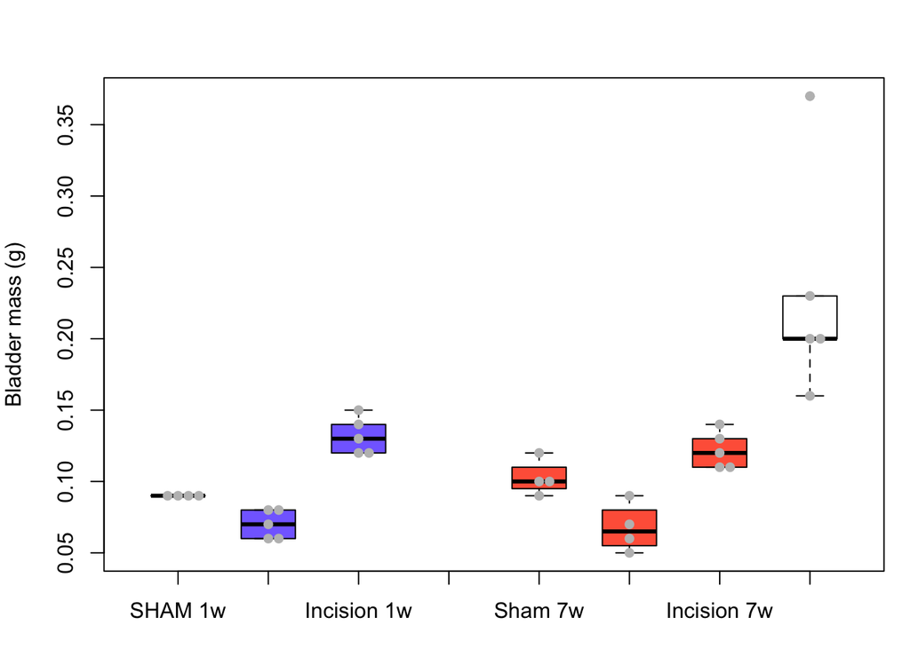

```r
#bladder mass graph:

f <- ordered(interaction(stcp$Group,stcp$weeks),
levels = c("SHAM.1wk", "STC.1wk","Incision.1wk", "PBO.1wk","SHAM.7wk", "STC.7wk","Incision.7wk", "PBO.7wk"))
par(mar=c(3,4,3,1))
boxplot(bladder.weight ~ f, data =stcp,pch = 18, xlab = "",ylab = "Bladder mass (g)", boxwex=0.6 ,col=c("slateblue1","slateblue1","slateblue1","slateblue1","tomato","tomato","tomato","white"),names= c("SHAM 1w", "STC 1w","Incision 1w", "", "Sham 7w", "STC 7w","Incision 7w", "PBO 7w"))
beeswarm(bladder.weight ~ f, data =stcp, pch = 16, xlab = "", las = 2,cex.axis=1, ylab = "Bladder mass (g)",
names= c("SHAM 1w", "STC 1w","Incision 1w", "", "Sham 7w", "STC 7w","Incision 7w", "PBO 7w"),col= "grey", cex.axis = 0.8, cex.lab = 0.8, add=TRUE)
```

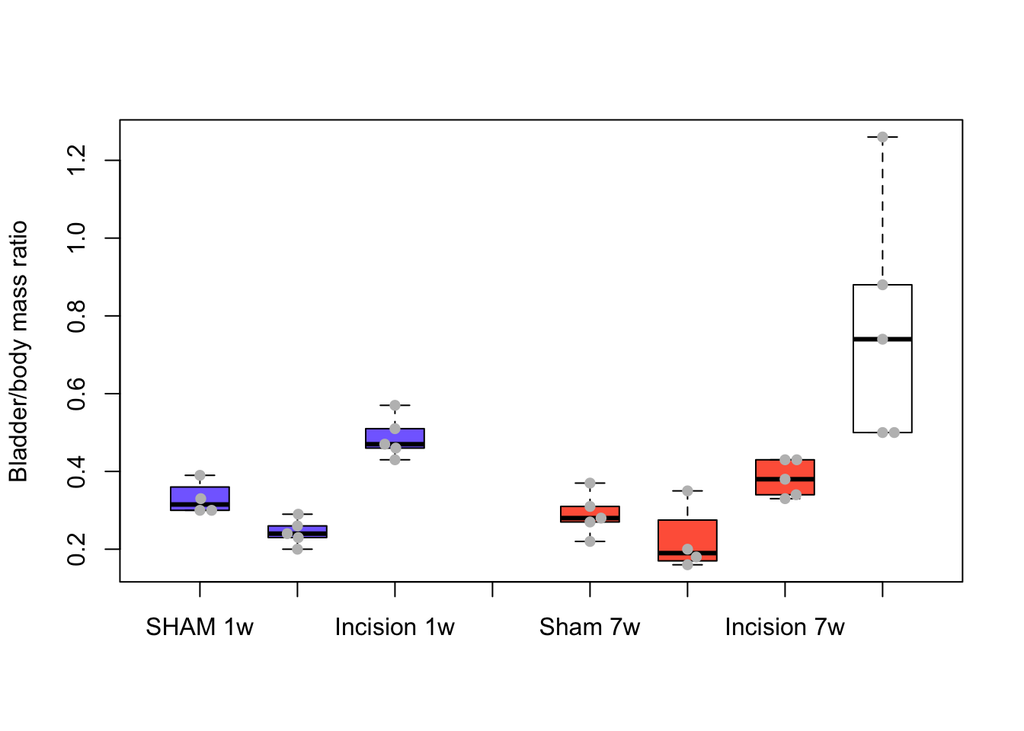

```r
#bladder ratio data:

f <- ordered(interaction(stcp$Group,stcp$weeks),
levels = c("SHAM.1wk", "STC.1wk","Incision.1wk", "PBO.1wk","SHAM.7wk", "STC.7wk","Incision.7wk", "PBO.7wk"))
boxplot(ratiobladder ~ f, data =stcp,pch = 18, xlab = "",ylab = "Bladder/body mass ratio", boxwex=0.6 ,col=c("slateblue1","slateblue1","slateblue1","slateblue1","tomato","tomato","tomato","white"),names= c("SHAM 1w", "STC 1w","Incision 1w", "", "Sham 7w", "STC 7w","Incision 7w", "PBO 7w"))
beeswarm(ratiobladder ~ f, data =stcp, pch = 16, xlab = "", las = 2,cex.axis=1, ylab = "Bladder/body mass ratio",
names= c("SHAM 1w", "STC 1w","Incision 1w", "", "Sham 7w", "STC 7w","Incision 7w", "PBO 7w"),col= "grey", cex.axis = 0.8, cex.lab = 0.8, add=TRUE)
```

PCR in vivo data:

```r
View(stcp)

f <- ordered(interaction(stcp$Group,stcp$weeks),
          levels = c("SHAM.1wk", "STC.1wk","Incision.1wk", "PBO.1wk","SHAM.7wk", "STC.7wk","Incision.7wk", "PBO.7wk"))

library(dplyr)
```

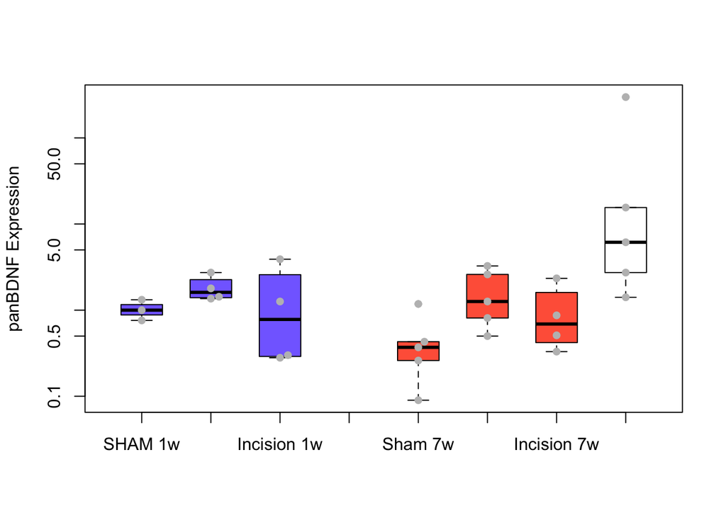

```r
#rename column since not easily read in by R
names(stcp)[20]<-"panBDNFlin"

boxplot(panBDNFlin ~ f, data =stcp, pch = 18, log = "y", xlab = "",ylab = "panBDNF Expression",boxwex=0.6,col=c("slateblue1","slateblue1","slateblue1","slateblue1","tomato","tomato","tomato","white"),alpha = 0.5, names= c("SHAM 1w", "STC 1w","Incision 1w", "", "Sham 7w", "STC 7w","Incision 7w", "PBO 7w"))
beeswarm(panBDNFlin ~ f, data =stcp, pch = 16, xlab = "", las = 2,cex.axis=1, ylab = "panBDNF Expression", names= c("SHAM 1w", "STC 1w","Incision 1w", "", "Sham 7w", "STC 7w","Incision 7w", "PBO 7w"),col= "grey", cex.axis = 0.8, cex.lab = 0.8, add=TRUE)
```

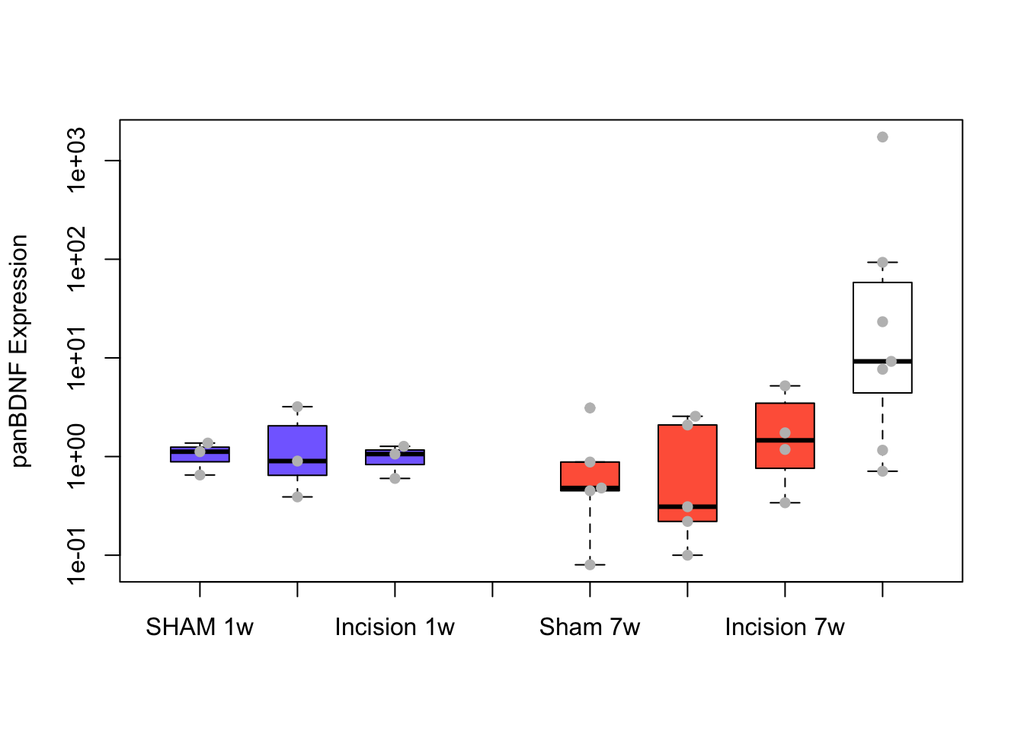

```r
boxplot(bdnf.var1 ~ f, data =stcp, pch = 18, log = "y", xlab = "",ylab = "panBDNF Expression", boxwex=0.6 ,col=c("slateblue1","slateblue1","slateblue1","slateblue1","tomato","tomato","tomato","white"),alpha = 0.5, names= c("SHAM 1w", "STC 1w","Incision 1w", "", "Sham 7w", "STC 7w","Incision 7w", "PBO 7w"))
beeswarm(bdnf.var1 ~ f, data =stcp, pch = 16, xlab = "", las = 2,cex.axis=1, ylab = "panBDNF Expression", names= c("SHAM 1w", "STC 1w","Incision 1w", "", "Sham 7w", "STC 7w","Incision 7w", "PBO 7w"),col= "grey", cex.axis = 0.8, cex.lab = 0.8, add=TRUE)
```

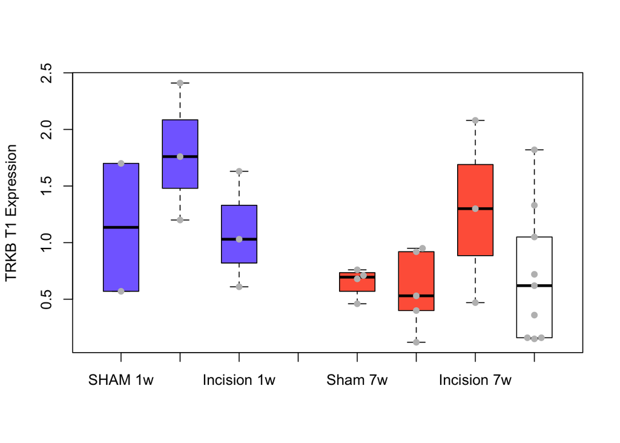

```r
boxplot(TrkBT1lin ~ f, data =stcp,pch = 18, xlab = "", ylab = "TRKB T1 Expression", boxwex=0.6 ,col=c("slateblue1","slateblue1","slateblue1","slateblue1","tomato","tomato","tomato","white"),alpha = 0.5, names= c("SHAM 1w", "STC 1w","Incision 1w", "", "Sham 7w", "STC 7w","Incision 7w", "PBO 7w"))
beeswarm(TrkBT1lin ~ f, data =stcp, pch = 16, xlab = "", las = 2,cex.axis=1, ylab = "TRKB T1 Expression", names= c("SHAM 1w", "STC 1w","Incision 1w", "", "Sham 7w", "STC 7w","Incision 7w", "PBO 7w"),col= "grey", cex.axis = 0.8, cex.lab = 0.8, add=TRUE)
```

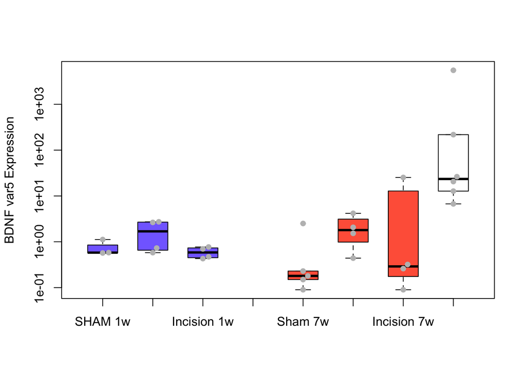

```r
boxplot(bdnfvar5linear ~ f, data =stcp, log="y", pch = 18, xlab = "",ylab = "BDNF var5 Expression", boxwex=0.6 ,col=c("slateblue1","slateblue1","slateblue1","slateblue1","tomato","tomato","tomato","white"),alpha = 0.5, names= c("SHAM 1w", "STC 1w","Incision 1w", "", "Sham 7w", "STC 7w","Incision 7w", "PBO 7w"))
beeswarm(bdnfvar5linear ~ f, data =stcp, pch = 16, xlab = "", las = 2,cex.axis=1, ylab = "BDNF var5 Expression", names= c("SHAM 1w", "STC 1w","Incision 1w", "", "Sham 7w", "STC 7w","Incision 7w", "PBO 7w"),col= "grey", cex.axis = 0.8, cex.lab = 0.8, add=TRUE)
```

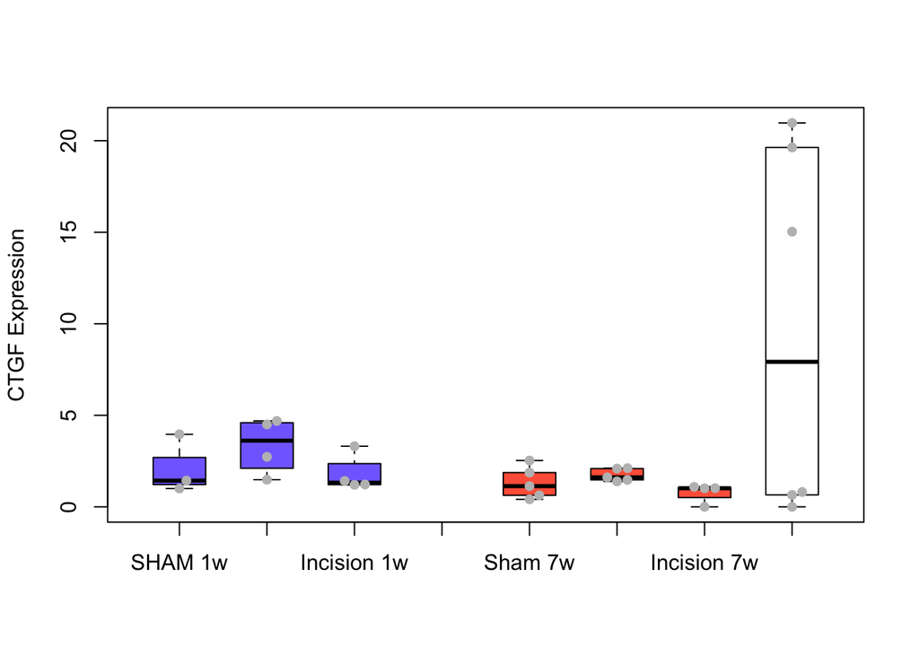

```r
f <- ordered(interaction(stcp[c(1:23,25:41),]$Group,stcp[c(1:23,25:41),]$weeks), levels = c("SHAM.1wk", "STC.1wk","Incision.1wk", "PBO.1wk","SHAM.7wk", "STC.7wk","Incision.7wk", "PBO.7wk"))

boxplot(CTGFlinear ~ f, data =stcp[c(1:23,25:41),],pch = 18, xlab = "", ylab = "CTGF Expression", boxwex=0.6 ,col=c("slateblue1","slateblue1","slateblue1","slateblue1","tomato","tomato","tomato","white"),alpha = 0.5, names= c("SHAM 1w", "STC 1w","Incision 1w", "", "Sham 7w", "STC 7w","Incision 7w", "PBO 7w"))
beeswarm(CTGFlinear ~ f, data =stcp[c(1:23,25:41),], pch = 16, xlab = "", las = 2,cex.axis=1, ylab = "CTGF Expression", names= c("SHAM 1w", "STC 1w","Incision 1w", "", "Sham 7w", "STC 7w","Incision 7w", "PBO 7w"),col= "grey", cex.axis = 0.8, cex.lab = 0.8, add=TRUE)
```

```r
#Cyr61 data in separate file.
PCR_sheets_in_vivo<-read_csv("https://raw.githubusercontent.com/kjaitken/STC_repository/main/github%20datasets/PCR_sheets_in_vivo.csv")
```

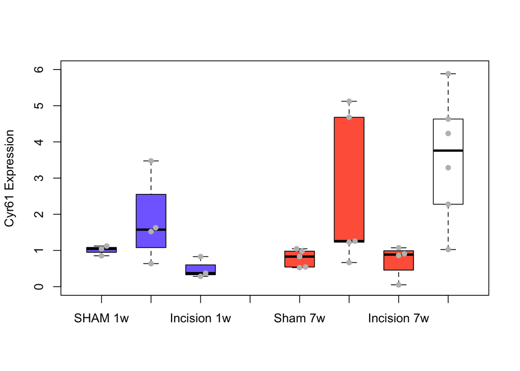

```r
stcp1<-PCR_sheets_in_vivo
f <- ordered(interaction(stcp1$Group,stcp1$weeks), levels = c("SHAM.1wk", "STC.1wk","Incision.1wk", "PBO.1wk","SHAM.7wk", "STC.7wk","Incision.7wk", "PBO.7wk"))

boxplot(cyr61lin ~ f, data =stcp1,  pch = 18, xlab = "",ylab = "Cyr61 Expression", boxwex=0.6 ,col=c("slateblue1","slateblue1","slateblue1","slateblue1","tomato","tomato","tomato","white"),ylim = c(0,6), names= c("SHAM 1w", "STC 1w","Incision 1w", "", "Sham 7w", "STC 7w","Incision 7w", "PBO 7w"))
beeswarm(cyr61lin ~ f, data =stcp1, pch = 16, xlab = "", las = 2,cex.axis=1, ylab = "Cyr61 Expression", names= c("SHAM 1w", "STC 1w","Incision 1w", "", "Sham 7w", "STC 7w","Incision 7w", "PBO 7w"),col= "grey", cex.axis = 0.8, cex.lab = 0.8, add = TRUE)
```

Cell Migration data

```r
library(beeswarm)
library(readr)

#upload data from github:
mn <-read_csv("https://raw.githubusercontent.com/kjaitken/STC_repository/main/github%20datasets/mn.csv")
```

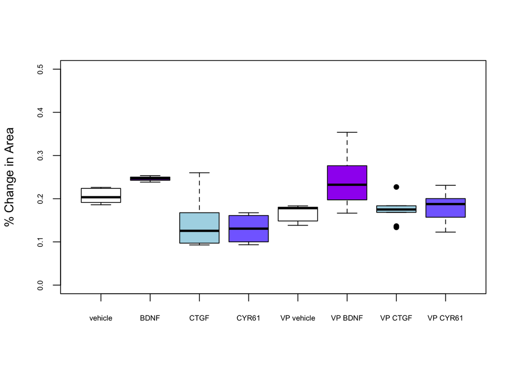

```r
f <- ordered(interaction(mn$GF,mn$inhibition),levels = c("veh.veh","BDNF_high.veh","CTGF.veh","CYR61.veh","veh.VP","BDNF_high.VP","CTGF.VP","CYR61.VP"))

boxplot(percent.change.area ~ f, data =mn,pch = 16, xlab = "", cex.axis=.6, ylab = "% Change in Area",col=c("white","purple","lightblue","slateblue1","white","purple","light blue","slateblue1"), ylim = c(0, .5), names = c("vehicle","BDNF","CTGF","CYR61","VP vehicle","VP BDNF","VP CTGF","VP CYR61"))
```

```r
#NB: variable number of samples per group in this experiment was due to variability in the scratches. Some attempts at scratches did not work, and had only a tiny dot of cells removed.
```

Nerve density pic analysis: Volocity parameters utilized to identify the cell types based on regions around positive SMC markers, and the nuclei by HOECHST staining. Then the intensity of the nuclear and non-nuclear YAP staining was evaluated for each cell on each slide. Data was exported into a csv for analysis on R.

```r
library(readr)
aggr_sample1 <- read_csv("https://raw.githubusercontent.com/kjaitken/STC_repository/main/github%20datasets/aggr_sample1.csv")
```

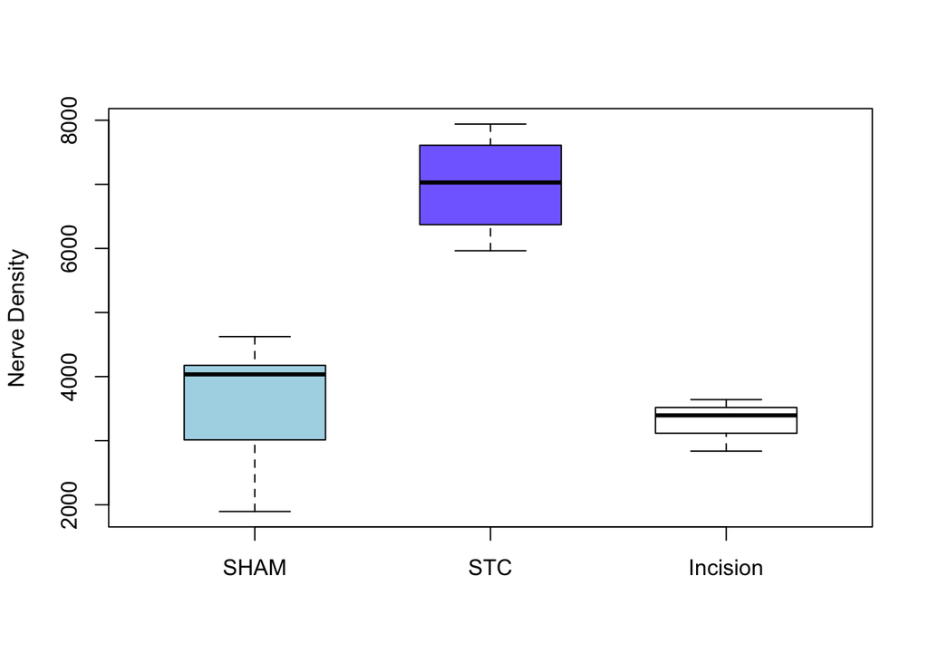

```r
View(aggr_sample1)

f <- ordered(aggr_sample1$Group,
levels = c("sham", "STC7week","incisioncontrol"))
boxplot(nervefr ~ f, data =aggr_sample1,pch = 18, xlab = "",ylab = "Nerve Density", boxwex=0.6 ,col=c("lightblue","slateblue1","white"),names= c("SHAM", "STC","Incision"))
```

```r
#Non-SMC region nerves
#provide a github link to the data
library(readr)
# load data from github
aggr_sample <- read_csv("https://raw.githubusercontent.com/kjaitken/STC_repository/main/github%20datasets/aggr_sample.csv")
```

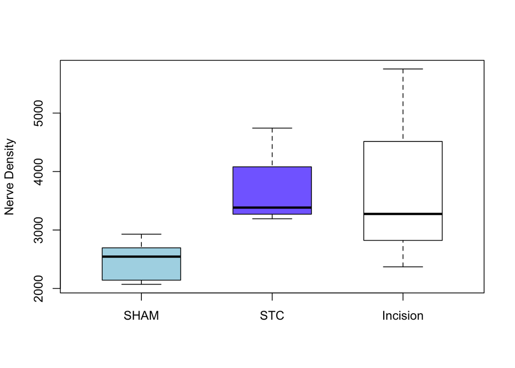

```r
#STC sample in first row is a high outlier with value >15000, and is left out.
f <- ordered(aggr_sample[2:19,]$Group,levels = c("sham", "STC7weeks","incisioncontrol"))
boxplot(nervefr ~ f, data =aggr_sample[2:19,],pch = 18, xlab = "",ylab = "Nerve Density", boxwex=0.6 ,col=c("lightblue","slateblue1","white"),names= c("SHAM", "STC","Incision"))
```